# Binary Classification Model for Bank Marketing Using R Take #3

David Lowe

May 11, 2018

Template Credit: Adapted from a template made available by Dr. Jason Brownlee of Machine Learning Mastery (http://machinelearningmastery.com/)

Dataset Used: Bank Marketing Data Set

Data Set ML Model: Binary classification with numerical and categorical attributes

Dataset Reference: http://archive.ics.uci.edu/ml/datasets/bank+marketing

One source of potential performance benchmarks: https://www.kaggle.com/rouseguy/bankbalanced

INTRODUCTION: The Bank Marketing dataset involves predicting the whether the bank clients will subscribe (yes/no) a term deposit (target variable). It is a binary (2-class) classification problem. There are over 41,000 observations with 19 input variables and 1 output variable. There are no missing values within the dataset. This dataset is based on “Bank Marketing” UCI dataset and is enriched by the addition of five new social and economic features/attributes. This dataset is almost identical to the one without the five new attributes.

CONCLUSION: The take No.3 version of this banking dataset aims to test the addition of five additional social-economical attributes to the dataset and the effect. You can see the results from the take No.2 here on the website: https://daines-analytics.com/wp-content/uploads/2018/05/r-classification-Bank_Marketing_Take2.html.

Stochastic Gradient Boosting also processed the validation dataset with an accuracy of 90.00%, which was sufficiently close to the training result. For this project, the Stochastic Gradient Boosting ensemble algorithm yielded consistently top-notch training and validation results, which warrant the additional processing required by the algorithm. The addition of the social-economical attributes did not seem to have a substantial effect on the overall accuracy of the prediction models.

The purpose of this project is to analyze predictions using various machine learning algorithms and to document the steps using a template. Working through machine learning problems from end-to-end requires a structured modeling approach. Working problems through a project template can also encourage us to think about the problem more critically, to challenge our assumptions, and to get proficient at all parts of a modeling project.

The project aims to touch on the following areas:

1. Document a predictive modeling problem end-to-end.
2. Explore data cleaning and transformation options
3. Explore non-ensemble and ensemble algorithms for baseline model performance
4. Explore algorithm tuning techniques for improving model performance

Any predictive modeling machine learning project genrally can be broken down into about six major tasks:

1. Prepare Problem
2. Summarize Data
3. Prepare Data
4. Model and Evaluate Algorithms
5. Improve Accuracy or Results
6. Finalize Model and Present Results

## 1. Prepare Problem

### 1.a) Load libraries

```r
library(caret)
library(ROCR)
```

### 1.b) Load training

```r
startTimeScript <- proc.time()
entireDataset <- read.csv2("bank-additional-full.csv", header= TRUE)

#Dropping the duration column to prevent future from leaking into the present
entireDataset$duration <- NULL

#Adjusting some factor columns back into numeric
entireDataset$emp.var.rate <- as.numeric(as.character(entireDataset$emp.var.rate))
entireDataset$cons.price.idx <- as.numeric(as.character(entireDataset$cons.price.idx))
entireDataset$cons.conf.idx <- as.numeric(as.character(entireDataset$cons.conf.idx))
entireDataset$euribor3m <- as.numeric(as.character(entireDataset$euribor3m))
entireDataset$nr.employed <- as.numeric(as.character(entireDataset$nr.employed))

# Use variable totCol to hold the number of columns in the dataframe
totCol <- ncol(entireDataset)

# Rename the class column to a standard label
colnames(entireDataset)[ncol(entireDataset)] <- "targetVar"
```

## 2. Summarize Data

To gain a better understanding of the data that we have on-hand, we will leverage a number of descriptive statistics and data visualization techniques. The plan is to use the results to consider new questions, review assumptions, and validate hypotheses that we can investigate later with specialized models.

### 2.a) Descriptive statistics

#### 2.a.i) Peek at the data itself.

```r
head(entireDataset)
```

```
##   age       job marital   education default housing loan   contact month
## 1  56 housemaid married    basic.4y      no      no   no telephone   may
## 2  57  services married high.school unknown      no   no telephone   may
## 3  37  services married high.school      no     yes   no telephone   may
## 4  40    admin. married    basic.6y      no      no   no telephone   may
## 5  56  services married high.school      no      no  yes telephone   may
## 6  45  services married    basic.9y unknown      no   no telephone   may
##   day_of_week campaign pdays previous    poutcome emp.var.rate
## 1         mon        1   999        0 nonexistent          1.1
## 2         mon        1   999        0 nonexistent          1.1
## 3         mon        1   999        0 nonexistent          1.1
## 4         mon        1   999        0 nonexistent          1.1
## 5         mon        1   999        0 nonexistent          1.1
## 6         mon        1   999        0 nonexistent          1.1
##   cons.price.idx cons.conf.idx euribor3m nr.employed targetVar
## 1         93.994         -36.4     4.857        5191        no
## 2         93.994         -36.4     4.857        5191        no
## 3         93.994         -36.4     4.857        5191        no
## 4         93.994         -36.4     4.857        5191        no
## 5         93.994         -36.4     4.857        5191        no
## 6         93.994         -36.4     4.857        5191        no
```

#### 2.a.ii) Dimensions of the dataset.

```r
dim(entireDataset)
```

```
## [1] 41188    20
```

#### 2.a.iii) Types of the attributes.

```r
sapply(entireDataset, class)
```

```
##            age            job        marital      education        default
##      "integer"       "factor"       "factor"       "factor"       "factor"
##        housing           loan        contact          month    day_of_week
##       "factor"       "factor"       "factor"       "factor"       "factor"
##       campaign          pdays       previous       poutcome   emp.var.rate
##      "integer"      "integer"      "integer"       "factor"      "numeric"
## cons.price.idx  cons.conf.idx      euribor3m    nr.employed      targetVar
##      "numeric"      "numeric"      "numeric"      "numeric"       "factor"
```

#### 2.a.iv) Statistical summary of all attributes.

```r
summary(entireDataset)
```

```
##       age                 job            marital
##  Min.   :17.00   admin.     :10422   divorced: 4612
##  1st Qu.:32.00   blue-collar: 9254   married :24928
##  Median :38.00   technician : 6743   single  :11568
##  Mean   :40.02   services   : 3969   unknown :   80
##  3rd Qu.:47.00   management : 2924
##  Max.   :98.00   retired    : 1720
##                  (Other)    : 6156
##                education        default         housing
##  university.degree  :12168   no     :32588   no     :18622
##  high.school        : 9515   unknown: 8597   unknown:  990
##  basic.9y           : 6045   yes    :    3   yes    :21576
##  professional.course: 5243
##  basic.4y           : 4176
##  basic.6y           : 2292
##  (Other)            : 1749
##       loan            contact          month       day_of_week
##  no     :33950   cellular :26144   may    :13769   fri:7827
##  unknown:  990   telephone:15044   jul    : 7174   mon:8514
##  yes    : 6248                     aug    : 6178   thu:8623
##                                    jun    : 5318   tue:8090
##                                    nov    : 4101   wed:8134
##                                    apr    : 2632
##                                    (Other): 2016
##     campaign          pdays          previous            poutcome
##  Min.   : 1.000   Min.   :  0.0   Min.   :0.000   failure    : 4252
##  1st Qu.: 1.000   1st Qu.:999.0   1st Qu.:0.000   nonexistent:35563
##  Median : 2.000   Median :999.0   Median :0.000   success    : 1373
##  Mean   : 2.568   Mean   :962.5   Mean   :0.173
##  3rd Qu.: 3.000   3rd Qu.:999.0   3rd Qu.:0.000
##  Max.   :56.000   Max.   :999.0   Max.   :7.000
##
##   emp.var.rate      cons.price.idx  cons.conf.idx     euribor3m
##  Min.   :-3.40000   Min.   :92.20   Min.   :-50.8   Min.   :0.634
##  1st Qu.:-1.80000   1st Qu.:93.08   1st Qu.:-42.7   1st Qu.:1.344
##  Median : 1.10000   Median :93.75   Median :-41.8   Median :4.857
##  Mean   : 0.08189   Mean   :93.58   Mean   :-40.5   Mean   :3.621
##  3rd Qu.: 1.40000   3rd Qu.:93.99   3rd Qu.:-36.4   3rd Qu.:4.961
##  Max.   : 1.40000   Max.   :94.77   Max.   :-26.9   Max.   :5.045
##
##   nr.employed   targetVar
##  Min.   :4964   no :36548
##  1st Qu.:5099   yes: 4640
##  Median :5191
##  Mean   :5167
##  3rd Qu.:5228
##  Max.   :5228
##
```

#### 2.a.v) Summarize the levels of the class attribute.

```r
entireDataset_x <- entireDataset[,1:(totCol-1)]
entireDataset_y <- entireDataset[,totCol]
cbind(freq=table(entireDataset_y), percentage=prop.table(table(entireDataset_y))*100)
```

```
##      freq percentage
## no  36548   88.73458
## yes  4640   11.26542
```

#### 2.a.vi) Count missing values.

```r
sapply(entireDataset, function(x) sum(is.na(x)))
```

```
##            age            job        marital      education        default
##              0              0              0              0              0
##        housing           loan        contact          month    day_of_week
##              0              0              0              0              0
##       campaign          pdays       previous       poutcome   emp.var.rate
##              0              0              0              0              0
## cons.price.idx  cons.conf.idx      euribor3m    nr.employed      targetVar
##              0              0              0              0              0
```

### 2.b) Data visualizations

#### 2.b.i) Univariate plots to better understand each attribute.

```r
# Set up a variable for the total number of attribute columns (totAttr)
totAttr <- totCol-1
# Set up the number of row and columns for visualization display. dispRow * dispCol should be >= totAttr
dispCol <- 4
if (totAttr%%dispCol == 0) {
dispRow <- totAttr%/%dispCol
} else {
dispRow <- (totAttr%/%dispCol) + 1
}
```

```r
# Boxplots for each attribute
#par(mfrow=c(dispRow,dispCol))
#for(i in 1:totAttr) {
#   boxplot(entireDataset[,i], main=names(entireDataset)[i])
#}
```

```r
# Histograms each attribute
#par(mfrow=c(dispRow,dispCol))
#for(i in 1:totAttr) {
#   hist(entireDataset[,i], main=names(entireDataset)[i])
#}
```

```r
# Density plot for each attribute
#par(mfrow=c(dispRow,dispCol))
#for(i in 1:totAttr) {
#   plot(density(entireDataset[,i]), main=names(entireDataset)[i])
#}
```

#### 2.b.ii) Multivariate plots to better understand the relationships between attributes

```r
# Scatterplot matrix colored by class
#pairs(targetVar~., data=entireDataset, col=training$targetVar)
```

```r
# Box and whisker plots for each attribute by class
#scales <- list(x=list(relation="free"), y=list(relation="free"))
#featurePlot(x=entireDataset_x, y=entireDataset_y, plot="box", scales=scales)
```

```r
# Density plots for each attribute by class value
#featurePlot(x=entireDataset_x, y=entireDataset_y, plot="density", scales=scales)
```

```r
# Correlation plot
#correlations <- cor(entireDataset_x)
#corrplot(correlations, method="circle")
```

## 3. Prepare Data

Some training may require additional preparation activities that will best exposes the structure of the problem and the relationships between the input attributes and the output variable. Some data-prep tasks might include:

- Cleaning data by removing duplicates, marking missing values and even imputing missing values.
- Feature selection where redundant features may be removed.
- Data transforms where attributes are scaled or redistributed in order to best expose the structure of the problem later to learning algorithms.

### 3.a) Data Cleaning

```r
# Not applicable for this iteration of the project.

# Mark missing values
#invalid <- 0
#entireDataset$some_col[entireDataset$some_col==invalid] <- NA

# Impute missing values
#entireDataset$some_col <- with(entireDataset, impute(some_col, mean))
```

### 3.b) Feature Selection

```r
# Not applicable for this iteration of the project.
```

### 3.c) Data Transforms

```r
# Not applicable for this iteration of the project.
```

### 3.d) Split-out training and validation trainings

We create a training training (variable name “training”) and a validation training (variable name “validation”).

```r
seedNum <- 888
set.seed(seedNum)

# Create a list of 70% of the rows in the original training we can use for training
training_index <- createDataPartition(entireDataset$targetVar, p=0.70, list=FALSE)

# Use 70% of data to training and testing the models
training <- entireDataset[training_index,]

# Select the remaining 30% of the data for validation
validation <- entireDataset[-training_index,]
```

## 4. Model and Evaluate Algorithms

After the data-prep, we next work on finding a workable model by evaluating a subset of machine learning algorithms that are good at exploiting the structure of the training. The typical evaluation tasks include:

- Defining test options such as cross validation and the evaluation metric to use.
- Spot checking a suite of linear and nonlinear machine learning algorithms.
- Comparing the estimated accuracy of algorithms.

Linear Algorithm: Logistic Regression

Non-Linear Algorithms: Decision Trees (CART), k-Nearest Neighbors, and Support Vector Machine

Ensemble Algorithms: Bagged CART, Random Forest, and Stochastic Gradient Boosting

The random number seed is reset before each run to ensure that the evaluation of each algorithm is performed using the same data splits. It ensures the results are directly comparable.

### 4.a) Set test options and evaluation metric

```r
# Run algorithms using 10-fold cross validation
control <- trainControl(method="repeatedcv", number=10, repeats=3)
metricTarget <- "Accuracy"
```

### 4.b) Generate models using linear algorithms

```r
# Logistic Regression (Classification)
startTimeModule <- proc.time()
set.seed(seedNum)
fit.glm <- train(targetVar~., data=training, method="glm", metric=metricTarget, trControl=control)
```

[output not shown]

[output cut: 34 more lines]

[output not shown]

```r
proc.time()-startTimeModule
```

```
##    user  system elapsed
##   38.52    1.17   39.77
```

### 4.c) Generate models using nonlinear algorithms

```r
# Decision Tree - CART (Regression/Classification)
startTimeModule <- proc.time()
set.seed(seedNum)
fit.cart <- train(targetVar~., data=training, method="rpart", metric=metricTarget, trControl=control)
proc.time()-startTimeModule
```

```
##    user  system elapsed
##   21.02    0.47   21.53
```

```r
# k-Nearest Neighbors (Regression/Classification)
startTimeModule <- proc.time()
set.seed(seedNum)
fit.knn <- train(targetVar~., data=training, method="knn", metric=metricTarget, trControl=control)
proc.time()-startTimeModule
```

```
##    user  system elapsed
##  669.82    0.53  679.17
```

```r
# Support Vector Machine (Classification)
startTimeModule <- proc.time()
set.seed(seedNum)
fit.svm <- train(targetVar~., data=training, method="svmRadial", metric=metricTarget, trControl=control)
proc.time()-startTimeModule
```

```
##     user   system  elapsed
## 16146.29    67.41 16234.38
```

### 4.d) Generate models using ensemble algorithms

In this section, we will explore the use and tuning of ensemble algorithms to see whether we can improve the results.

```r
# Bagged CART (Regression/Classification)
startTimeModule <- proc.time()
set.seed(seedNum)
fit.bagcart <- train(targetVar~., data=training, method="treebag", metric=metricTarget, trControl=control)
proc.time()-startTimeModule
```

```
##    user  system elapsed
##  626.14    4.67  631.29
```

```r
# Random Forest (Regression/Classification)
startTimeModule <- proc.time()
set.seed(seedNum)
fit.rf <- train(targetVar~., data=training, method="rf", metric=metricTarget, trControl=control)
proc.time()-startTimeModule
```

```
##    user  system elapsed
## 9841.14   22.01 9871.03
```

```r
# Stochastic Gradient Boosting (Regression/Classification)
startTimeModule <- proc.time()
set.seed(seedNum)
fit.gbm <- train(targetVar~., data=training, method="gbm", metric=metricTarget, trControl=control, verbose=F)
proc.time()-startTimeModule
```

```
##    user  system elapsed
##  491.87    0.49  492.84
```

### 4.e) Compare baseline algorithms

```r
results <- resamples(list(LogReg=fit.glm, CART=fit.cart, kNN=fit.knn, SVM=fit.svm, BagCART=fit.bagcart, RF=fit.rf, GBM=fit.gbm))
summary(results)
```

```
##
## Call:
## summary.resamples(object = results)
##
## Models: LogReg, CART, kNN, SVM, BagCART, RF, GBM
## Number of resamples: 30
##
## Accuracy
##              Min.   1st Qu.    Median      Mean   3rd Qu.      Max. NA's
## LogReg  0.8938606 0.8974337 0.8997398 0.8997987 0.9021239 0.9056538    0
## CART    0.8921263 0.8970871 0.8995664 0.8992786 0.9019505 0.9066944    0
## kNN     0.8848422 0.8902185 0.8943991 0.8936252 0.8963245 0.9032258    0
## SVM     0.8938606 0.8973381 0.8994103 0.8994405 0.9020985 0.9046133    0
## BagCART 0.8741331 0.8846121 0.8884843 0.8876944 0.8911724 0.8956311    0
## RF      0.8935137 0.8967042 0.8989076 0.8987006 0.9000694 0.9039195    0
## GBM     0.8935137 0.8984917 0.9004509 0.9005388 0.9022107 0.9070413    0
##
## Kappa
##              Min.   1st Qu.    Median      Mean   3rd Qu.      Max. NA's
## LogReg  0.2582233 0.2855573 0.3081044 0.3057148 0.3201322 0.3434394    0
## CART    0.2109506 0.2915926 0.3189433 0.3113406 0.3310008 0.3587512    0
## kNN     0.2578638 0.2931185 0.3095048 0.3108258 0.3275224 0.3806545    0
## SVM     0.2262629 0.2591501 0.2736267 0.2762899 0.2923159 0.3395706    0
## BagCART 0.2508844 0.3065660 0.3183762 0.3227661 0.3401950 0.3728170    0
## RF      0.1863279 0.2172637 0.2344926 0.2360715 0.2555679 0.2926645    0
## GBM     0.2733769 0.3029697 0.3129992 0.3169705 0.3269335 0.3893233    0
```

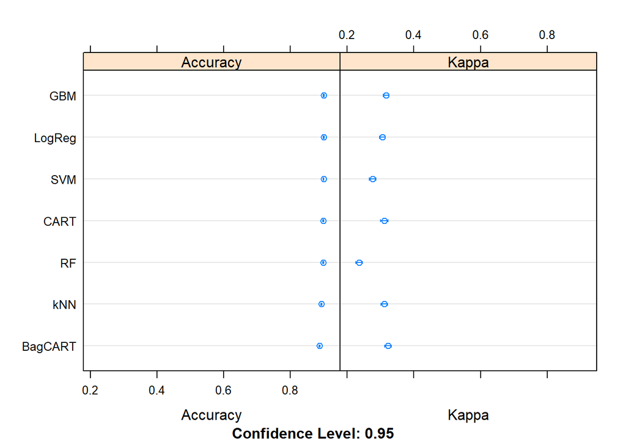

```r
dotplot(results)
```

## 5. Improve Accuracy or Results

After we achieve a short list of machine learning algorithms with good level of accuracy, we can leverage ways to improve the accuracy of the models:

- Search for a combination of parameters for each algorithm using caret that yields the best results.
- Combine the prediction of multiple models into an ensemble prediction using standalone algorithms or the caret Ensemble package.

### 5.a) Algorithm Tuning

```r
# Tuning algorithm #1 - Logistic Regression
# Logistic Regression requires no special tuning parameters with Caret
startTimeModule <- proc.time()
set.seed(seedNum)
fit.final1 <- fit.glm
print(fit.final1)
```

```
## Generalized Linear Model
##
## 28832 samples
##    19 predictor
##     2 classes: 'no', 'yes'
##
## No pre-processing
## Resampling: Cross-Validated (10 fold, repeated 3 times)
## Summary of sample sizes: 25949, 25950, 25949, 25949, 25949, 25948, ...
## Resampling results:
##
##   Accuracy   Kappa
##   0.8997987  0.3057148
```

```r
proc.time()-startTimeModule
```

```
##    user  system elapsed
##       0       0       0
```

```r
# Tuning algorithm #2 - Bagged CART
# Bagged CART requires no special tuning parameters with Caret
startTimeModule <- proc.time()
set.seed(seedNum)
fit.final2 <- fit.bagcart
print(fit.final2)
```

```
## Bagged CART
##
## 28832 samples
##    19 predictor
##     2 classes: 'no', 'yes'
##
## No pre-processing
## Resampling: Cross-Validated (10 fold, repeated 3 times)
## Summary of sample sizes: 25949, 25950, 25949, 25949, 25949, 25948, ...
## Resampling results:
##
##   Accuracy   Kappa
##   0.8876944  0.3227661
```

```r
proc.time()-startTimeModule
```

```
##    user  system elapsed
##       0       0       0
```

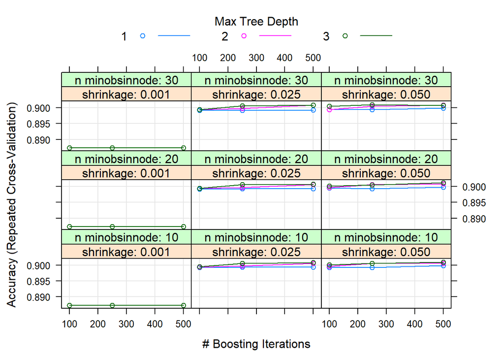

```r
# Tuning algorithm #3 - Stochastic Gradient Boosting
startTimeModule <- proc.time()
set.seed(seedNum)
grid <- expand.grid(.n.trees=c(100, 250, 500), .interaction.depth=c(1, 2, 3), .shrinkage=c(0.001, 0.025, 0.05), .n.minobsinnode=c(10, 20, 30))
fit.final3 <- train(targetVar~., data=training, method="gbm", metric=metricTarget, tuneGrid=grid, trControl=control, verbose=F)
plot(fit.final3)
```

```r
print(fit.final3)
```

```
## Stochastic Gradient Boosting
##
## 28832 samples
##    19 predictor
##     2 classes: 'no', 'yes'
##
## No pre-processing
## Resampling: Cross-Validated (10 fold, repeated 3 times)
## Summary of sample sizes: 25949, 25950, 25949, 25949, 25949, 25948, ...
## Resampling results across tuning parameters:
##
##   shrinkage  interaction.depth  n.minobsinnode  n.trees  Accuracy
##   0.001      1                  10              100      0.8873474
##   0.001      1                  10              250      0.8873474
##   0.001      1                  10              500      0.8873474
##   0.001      1                  20              100      0.8873474
##   0.001      1                  20              250      0.8873474
##   0.001      1                  20              500      0.8873474
##   0.001      1                  30              100      0.8873474
##   0.001      1                  30              250      0.8873474
##   0.001      1                  30              500      0.8873474
##   0.001      2                  10              100      0.8873474
##   0.001      2                  10              250      0.8873474
##   0.001      2                  10              500      0.8873474
##   0.001      2                  20              100      0.8873474
##   0.001      2                  20              250      0.8873474
##   0.001      2                  20              500      0.8873474
##   0.001      2                  30              100      0.8873474
##   0.001      2                  30              250      0.8873474
##   0.001      2                  30              500      0.8873474
##   0.001      3                  10              100      0.8873474
##   0.001      3                  10              250      0.8873474
##   0.001      3                  10              500      0.8873474
##   0.001      3                  20              100      0.8873474
##   0.001      3                  20              250      0.8873474
##   0.001      3                  20              500      0.8873474
##   0.001      3                  30              100      0.8873474
##   0.001      3                  30              250      0.8873474
##   0.001      3                  30              500      0.8873474
##   0.025      1                  10              100      0.8992440
```

[output cut: 124 more lines]

```
##   0.3016222
##   0.3142984
##   0.2889866
##   0.3126792
##   0.3274898
##   0.2885633
##   0.3126379
##   0.3295929
##   0.2911174
##   0.3158372
##   0.3236002
##
## Accuracy was used to select the optimal model using the largest value.
## The final values used for the model were n.trees = 500,
##  interaction.depth = 3, shrinkage = 0.05 and n.minobsinnode = 20.
```

```r
proc.time()-startTimeModule
```

```
##     user   system  elapsed
## 14077.65     2.80 14092.17
```

### 5.d) Compare Algorithms After Tuning

```r
results <- resamples(list(LR=fit.final1, BagCART=fit.final2, GBM=fit.final3))
summary(results)
```

```
##
## Call:
## summary.resamples(object = results)
##
## Models: LR, BagCART, GBM
## Number of resamples: 30
##
## Accuracy
##              Min.   1st Qu.    Median      Mean   3rd Qu.      Max. NA's
## LR      0.8938606 0.8974337 0.8997398 0.8997987 0.9021239 0.9056538    0
## BagCART 0.8741331 0.8846121 0.8884843 0.8876944 0.8911724 0.8956311    0
## GBM     0.8928200 0.8990031 0.9009712 0.9011053 0.9035811 0.9063476    0
##
## Kappa
##              Min.   1st Qu.    Median      Mean   3rd Qu.      Max. NA's
## LR      0.2582233 0.2855573 0.3081044 0.3057148 0.3201322 0.3434394    0
## BagCART 0.2508844 0.3065660 0.3183762 0.3227661 0.3401950 0.3728170    0
## GBM     0.2930827 0.3142709 0.3325974 0.3295929 0.3421108 0.3890789    0
```

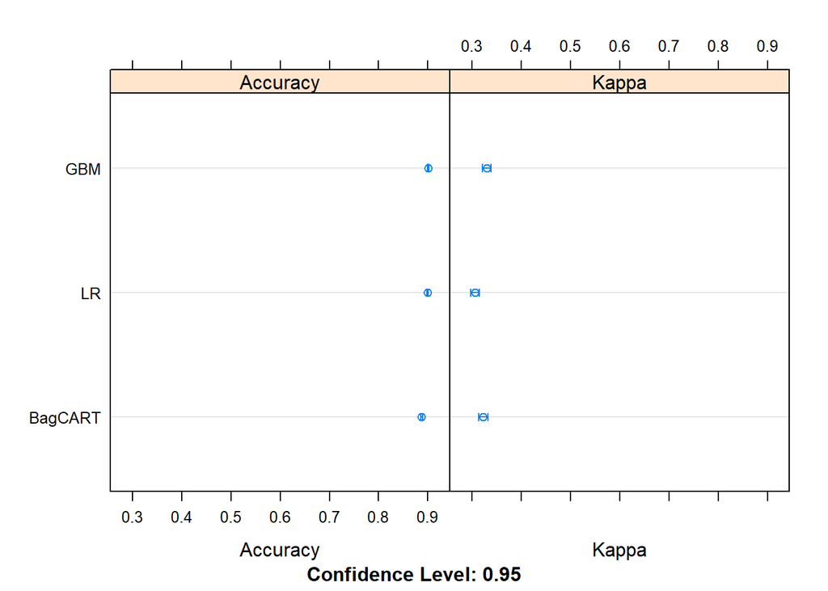

```r
dotplot(results)
```

## 6. Finalize Model and Present Results

Once we have narrow down to a model that we believe can make accurate predictions on unseen data, we are ready to finalize it. Finalizing a model may involve sub-tasks such as:

- Using an optimal model tuned to make predictions on unseen data.
- Creating a standalone model using the tuned parameters
- Saving an optimal model to file for later use.

### 6.a) Predictions on validation training

```r
predictClass <- predict(fit.final3, newdata=validation)
confusionMatrix(predictClass, validation$targetVar)
```

```
## Confusion Matrix and Statistics
##
##           Reference
## Prediction    no   yes
##        no  10769  1041
##        yes   195   351
##
##                Accuracy : 0.9
##                  95% CI : (0.8945, 0.9052)
##     No Information Rate : 0.8873
##     P-Value [Acc > NIR] : 3.456e-06
##
##                   Kappa : 0.319
##  Mcnemar's Test P-Value : < 2.2e-16
##
##             Sensitivity : 0.9822
##             Specificity : 0.2522
##          Pos Pred Value : 0.9119
##          Neg Pred Value : 0.6429
##              Prevalence : 0.8873
##          Detection Rate : 0.8716
##    Detection Prevalence : 0.9558
##       Balanced Accuracy : 0.6172
##
##        'Positive' Class : no
##
```

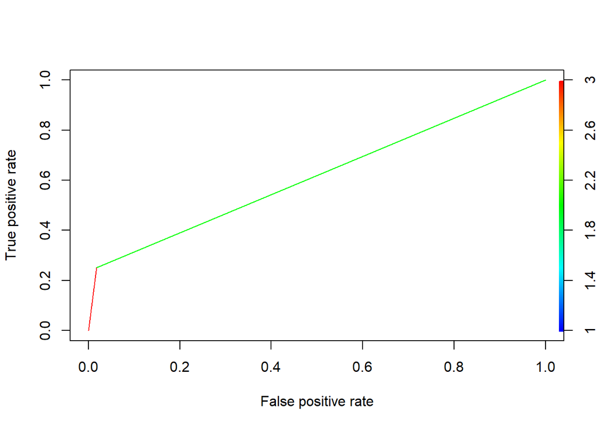

```r
pred <- prediction(as.numeric(predictClass), as.numeric(validation$targetVar))
perf <- performance(pred, measure = "tpr", x.measure = "fpr")
plot(perf, colorize=TRUE)
```

```r
auc <- performance(pred, measure = "auc")
auc <- auc@y.values[[1]]
auc
```

```
## [1] 0.6171848
```

### 6.b) Create standalone model from the entire training dataset

```r
library(gbm)
startTimeModule <- proc.time()
set.seed(seedNum)
grid <- expand.grid(.n.trees=500, .interaction.depth=3, .shrinkage=0.05, .n.minobsinnode=20)
finalModel <- train(targetVar~., data=entireDataset, method="gbm", metric=metricTarget, tuneGrid=grid, trControl=control, verbose=F)
print(finalModel)
```

```
## Stochastic Gradient Boosting
##
## 41188 samples
##    19 predictor
##     2 classes: 'no', 'yes'
##
## No pre-processing
## Resampling: Cross-Validated (10 fold, repeated 3 times)
## Summary of sample sizes: 37069, 37070, 37069, 37069, 37069, 37069, ...
## Resampling results:
##
##   Accuracy  Kappa
##   0.901112  0.3235136
##
## Tuning parameter 'n.trees' was held constant at a value of 500
##  3
## Tuning parameter 'shrinkage' was held constant at a value of
##  0.05
## Tuning parameter 'n.minobsinnode' was held constant at a value of 20
```

```r
proc.time()-startTimeModule
```

```
##    user  system elapsed
## 1093.73    0.25 1094.64
```

### 6.c) Save model for later use

```r
#saveRDS(finalModel, "./finalModel_BinaryClass.rds")
```

```r
proc.time()-startTimeScript
```

```
##     user   system  elapsed
## 43014.83   100.27 43166.05
```